# Movielens - Movie Recommendation System

Donghan Lee

10/25/2021

# 1. Introduction

```r
# Note: this process could take a couple of minutes

if(!require(tidyverse)) install.packages("tidyverse", repos = "http://cran.us.r-project.org")
if(!require(caret)) install.packages("caret", repos = "http://cran.us.r-project.org")
if(!require(data.table)) install.packages("data.table", repos = "http://cran.us.r-project.org")

library(tidyverse)
library(caret)
library(data.table)

# MovieLens 10M dataset:
# https://grouplens.org/datasets/movielens/10m/
# http://files.grouplens.org/datasets/movielens/ml-10m.zip

dl <- tempfile()
download.file("http://files.grouplens.org/datasets/movielens/ml-10m.zip", dl)

ratings <- fread(text = gsub("::", "\t", readLines(unzip(dl, "ml-10M100K/ratings.dat"))),
                 col.names = c("userId", "movieId", "rating", "timestamp"))

movies <- str_split_fixed(readLines(unzip(dl, "ml-10M100K/movies.dat")), "\\::", 3)
colnames(movies) <- c("movieId", "title", "genres")

# if using R 3.6 or earlier:
#movies <- as.data.frame(movies) %>% mutate(movieId = as.numeric(levels(movieId))[movieId],
#                                           title = as.character(title),
#                                           genres = as.character(genres))
# if using R 4.0 or later:
movies <- as.data.frame(movies) %>% mutate(movieId = as.numeric(movieId),
                                           title = as.character(title),
                                           genres = as.character(genres))


movielens <- left_join(ratings, movies, by = "movieId")

# Validation set will be 10% of MovieLens data
set.seed(1, sample.kind="Rounding") # if using R 3.5 or earlier, use `set.seed(1)`
test_index <- createDataPartition(y = movielens$rating, times = 1, p = 0.1, list = FALSE)
edx <- movielens[-test_index,]
temp <- movielens[test_index,]

# Make sure userId and movieId in validation set are also in edx set
validation <- temp %>%
  semi_join(edx, by = "movieId") %>%
  semi_join(edx, by = "userId")

# Add rows removed from validation set back into edx set
removed <- anti_join(temp, validation)
edx <- rbind(edx, removed)

rm(dl, ratings, movies, test_index, temp, removed)
```

# 2.1. Data Analysis

```r
# printing the first 10
movielens %>% head(10)
```

```
##     userId movieId rating timestamp                         title
##  1:      1     122      5 838985046              Boomerang (1992)
##  2:      1     185      5 838983525               Net, The (1995)
##  3:      1     231      5 838983392          Dumb & Dumber (1994)
##  4:      1     292      5 838983421               Outbreak (1995)
##  5:      1     316      5 838983392               Stargate (1994)
##  6:      1     329      5 838983392 Star Trek: Generations (1994)
##  7:      1     355      5 838984474       Flintstones, The (1994)
##  8:      1     356      5 838983653           Forrest Gump (1994)
##  9:      1     362      5 838984885       Jungle Book, The (1994)
## 10:      1     364      5 838983707         Lion King, The (1994)
##                                         genres
##  1:                             Comedy|Romance
##  2:                      Action|Crime|Thriller
##  3:                                     Comedy
##  4:               Action|Drama|Sci-Fi|Thriller
##  5:                    Action|Adventure|Sci-Fi
##  6:              Action|Adventure|Drama|Sci-Fi
##  7:                    Children|Comedy|Fantasy
##  8:                   Comedy|Drama|Romance|War
##  9:                 Adventure|Children|Romance
## 10: Adventure|Animation|Children|Drama|Musical
```

structure of data

```r
# structure of data
str(movielens)
```

```
## Classes 'data.table' and 'data.frame':   10000054 obs. of  6 variables:
##  $ userId   : int  1 1 1 1 1 1 1 1 1 1 ...
##  $ movieId  : num  122 185 231 292 316 329 355 356 362 364 ...
##  $ rating   : num  5 5 5 5 5 5 5 5 5 5 ...
##  $ timestamp: int  838985046 838983525 838983392 838983421 838983392 838983392 838984474 838983653 838984885 838983707 ...
##  $ title    : chr  "Boomerang (1992)" "Net, The (1995)" "Dumb & Dumber (1994)" "Outbreak (1995)" ...
##  $ genres   : chr  "Comedy|Romance" "Action|Crime|Thriller" "Comedy" "Action|Drama|Sci-Fi|Thriller" ...
##  - attr(*, ".internal.selfref")=<externalptr>
```

dimension of data

```r
# dimension of data
dim(movielens)
```

```
## [1] 10000054        6
```

distribution of rating

```r
# rating distribution
movielens %>% group_by(rating) %>% summarize(n = n())
```

```
## # A tibble: 10 × 2
##    rating       n
##     <dbl>   <int>
##  1    0.5   94988
##  2    1    384180
##  3    1.5  118278
##  4    2    790306
##  5    2.5  370178
##  6    3   2356676
##  7    3.5  879764
##  8    4   2875850
##  9    4.5  585022
## 10    5   1544812
```

unique user and movie

```r
# finding how mamy unique userId and movieId
movielens %>%
  summarize(n_users = n_distinct(userId),
            n_movies = n_distinct(movieId))
```

```
##   n_users n_movies
## 1   69878    10677
```

```r
library(dplyr)
library(knitr)


# top 5 of number of movie
keep <- movielens %>%
  count(movieId) %>%
  top_n(5) %>%
  pull(movieId)
# select userId 10-15 and show the rating
tab <- movielens %>%
  filter(userId %in% c(10:13)) %>%
  filter(movieId %in% keep) %>%
  select(userId, title, rating) %>%
  spread(title, rating)

tab %>% kable()
```

| userId | Forrest Gump (1994) | Jurassic Park (1993) | Pulp Fiction (1994) | Silence of the Lambs, The (1991) |
| --- | --- | --- | --- | --- |
| 10 | 3 | NA | 2 | 3 |
| 11 | NA | 4 | 3 | NA |
| 13 | NA | NA | 4 | NA |

Sparseness of data

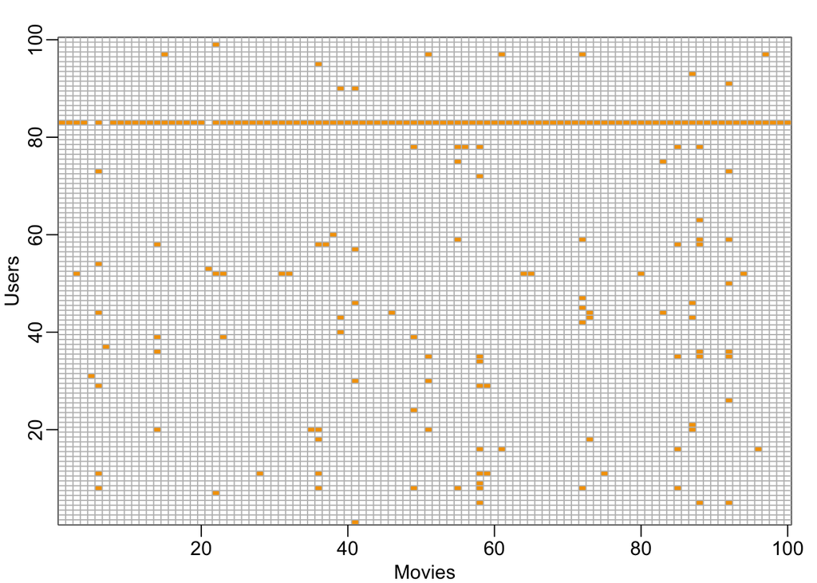

```r
# showing sparseness of data using heat map of movieId and userId
# select unique 100 users
users <- sample(unique(movielens$userId), 100)
rafalib::mypar()

movielens %>% filter(userId %in% users) %>% # select only 100 unique users
  select(userId, movieId, rating) %>% # get userId, movieId, and rating
  mutate(rating = 1) %>% # for heat map, set rating to 1
  spread(movieId, rating) %>% # make data as row with userId and column with movieId with value of rating
  select(sample(ncol(.), 100)) %>% # choose 100 movieId
  as.matrix() %>% # make as matrix
  t(.) %>% # transpose the matrix. So, row is movieId, column is userId
  image(1:100, 1:100,. , xlab="Movies", ylab="Users") # heat map
# create grid for easy look
abline(h=0:100+0.5, v=0:100+0.5, col = "grey")
```

How the rate of the movie is provide.

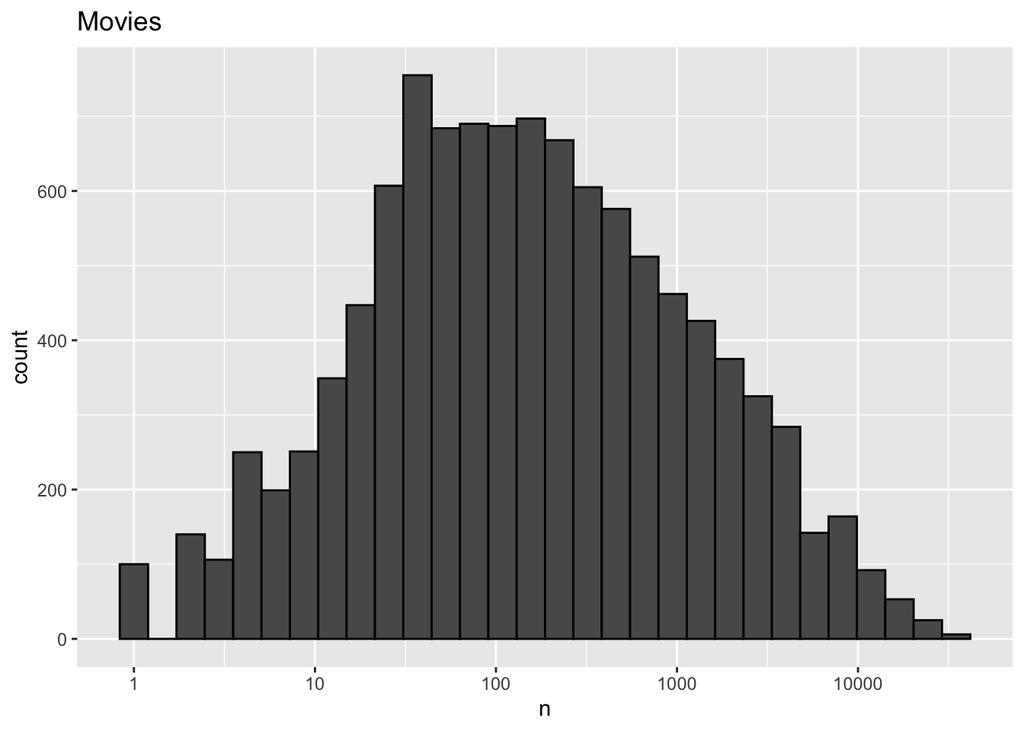

```r
# histogram of how the rate of the movie is provided.
movielens %>%
  count(movieId) %>%
  ggplot(aes(n)) +
  geom_histogram(bins = 30, color = "black") +
  scale_x_log10() +
  ggtitle("Movies")
```

How users provide rating

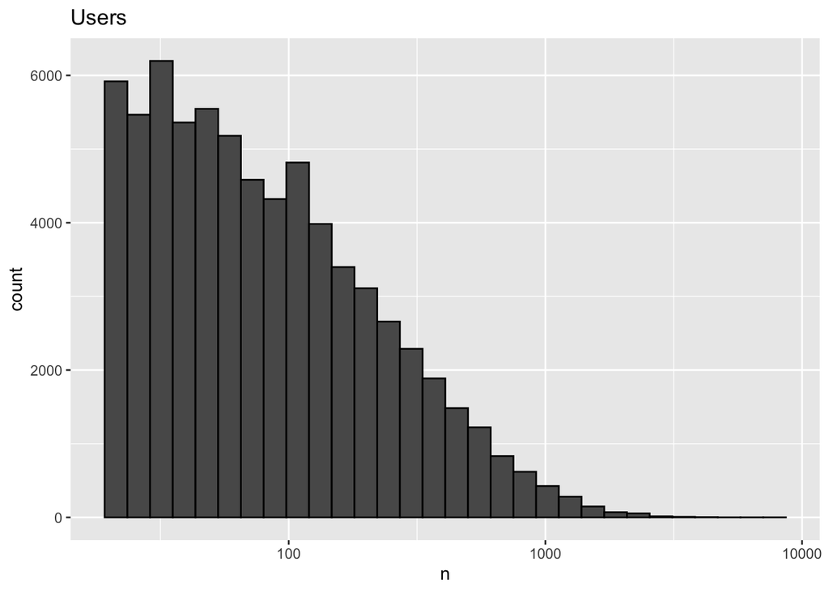

```r
# histogram of how users provide rating
movielens %>%
  count(userId) %>%
  ggplot(aes(n)) +
  geom_histogram(bins = 30, color = "black") +
  scale_x_log10() +
  ggtitle("Users")
```

rating period

```r
# rating period calculation. lubridate origin is 1970-01-01.
library(lubridate)
# first date, last day, and duration of rating
tibble(first_date = date(as_datetime(min(movielens$timestamp),
                                     origin="1970-01-01")),
       last_date = date(as_datetime(max(movielens$timestamp),
                                    origin="1970-01-01"))) %>%
  mutate(duration = duration(max(movielens$timestamp)-min(movielens$timestamp)))
```

```
## # A tibble: 1 × 3
##   first_date last_date  duration
##   <date>     <date>     <Duration>
## 1 1995-01-09 2009-01-05 441479727s (~13.99 years)
```

how many movies are rated in various years

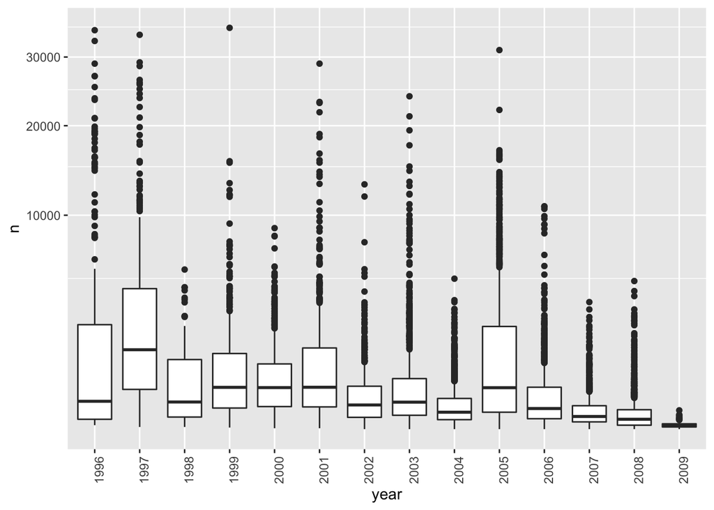

```r
## how many movies came out in various years. lubridate origin is 1970-01-01.
movielens %>%
  mutate(year = year(as_datetime(timestamp, origin="1970-01-01"))) %>%
  group_by(movieId) %>%
  summarize(n = n(), year = as.character(first(year))) %>%
  qplot(year, n, data = ., geom = "boxplot") +
  coord_trans(y = "sqrt") +
  theme(axis.text.x = element_text(angle = 90, hjust = 1))
```

Relationship between rate of rating on movie and rating

```r
# relationship between rate of rating on movie and rating
library(gam)
```

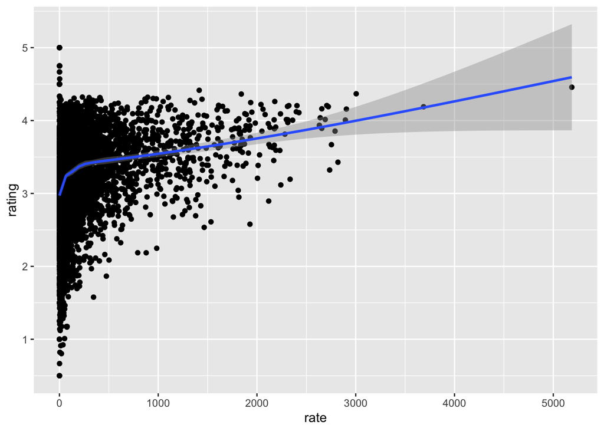

```r
movielens %>%
  mutate(year = year(as_datetime(timestamp, origin="1970-01-01"))) %>%
  group_by(movieId) %>%
  summarize(n = n(), years = 2011 - first(year),
            title = title[1],
            rating = mean(rating)) %>%
  mutate(rate = n/years) %>%
  ggplot(aes(rate, rating)) +
  geom_point() +
  geom_smooth()
```

[figure not shown]

```r
# how the rating is related with genres
# without considering muliple genres
movielens %>% group_by(genres) %>%
  summarize(n = n(), avg = mean(rating), se = sd(rating)/sqrt(n())) %>%
  filter(n >= 1000) %>%
  mutate(genres = reorder(genres, avg)) %>%
  ggplot(aes(x = genres, y = avg, ymin = avg - 2*se, ymax = avg + 2*se)) +
  geom_point() +
  geom_errorbar() +
  theme(axis.text.x = element_text(angle = 90, hjust = 1))
```

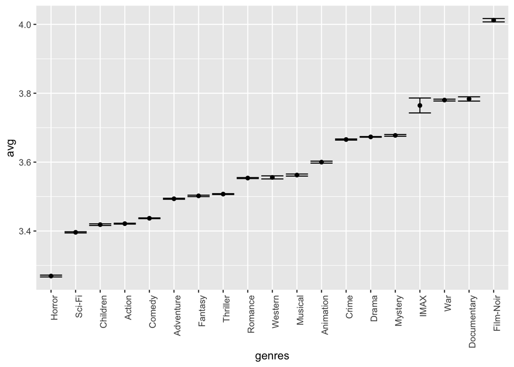

```r
# considering multiple genres in a movie
movielens %>% separate_rows(genres, sep = "\\|") %>% # genres could be multiple. First separate
  group_by(genres) %>%
  summarize(n = n(), avg = mean(rating), se = sd(rating)/sqrt(n())) %>%
  filter(n >= 1000) %>%
  mutate(genres = reorder(genres, avg)) %>%
  ggplot(aes(x = genres, y = avg, ymin = avg - 2*se, ymax = avg + 2*se)) +
  geom_point() +
  geom_errorbar() +
  theme(axis.text.x = element_text(angle = 90, hjust = 1))
```

# 2.2. Models

# 2.2.1. Navie estimate

$$P(Y) = \mu$$
# 2.2.2. Linear Model

# 2.2.2.1. Movie effect

$$Y = \mu + b_i$$
# 2.2.2.2. User effect
$$Y = \mu + b_i + b_u$$
# 2.2.2.4. year effect
$$Y_{u,i} = \mu + b_i + b_u + f(d_{u,i}) + \epsilon_{u,i}$$
with $f$ a smooth function of $d_{u,i}$

# 2.2.2.5. genres effect

$$Y_{u,i} = \mu + b_i + b_u + \sum_{k=1}^K x_{u,i}^k \beta_k + \epsilon_{u,i}$$
with $x_{u,i}^k = 1$ if $g_{u,i}$ is genre $k$

# 2.2.3. Regularization

# 2.2.4. Matrix Factorizing

$$Y_{u,i} \sim \sum_{m = 1}^k P_{i,m} * Q_{m,u}$$
# 3. Results

# 3.1. Cross Validation

edx from 2.0. creating data is divided into train (90%) and test (10%) sets for cross-validation.

```r
set.seed(1, sample.kind="Rounding") # if using R 3.5 or earlier, use `set.seed(1)`

# create train index p = 0.9
train_index <- createDataPartition(y = edx$rating, times = 1,
                                   p = 0.9, list = FALSE)

train <- edx[train_index,]
temp <- edx[-train_index,]

# Make sure userId and movieId in validation set are also in edx set
test <- temp %>%
  semi_join(train, by = "movieId") %>%
  semi_join(train, by = "userId")

# Add rows removed from test set back into train set
removed <- anti_join(temp, test)
train <- rbind(train, removed)

# clean up the workspace
rm(train_index, temp, removed)
```

Benchmark RMSE function

```r
RMSE <- function(predictions, true_ratings){
  sqrt(mean((true_ratings - predictions)^2))
}
```

# 3.1.1. Navie estimate

From 2.2.1,

```r
# average (mu) of rating in train set
mu <- mean(train$rating)

# prediction; rating is expected to be average for all.
predictions <- rep(mu, nrow(test))

# rmse from average
naive_rmse <- RMSE(predictions, test$rating)

# storing the rmse to rmse_results
rmse_results <- data_frame(method = "Just the average", RMSE = naive_rmse)
# print table for RMSE
rmse_results %>% kable()
```

| method | RMSE |
| --- | --- |
| Just the average | 1.059802 |

# 3.1.2.1 Movie effect

model: Y = mu + b_i + error ; where b_i for movieId rational: The contents of movie should be related to rating

```r
b_i <- train %>%
  group_by(movieId) %>%
  summarize(b_i = mean(rating - mu))

# prediction
predictions <- test %>%
  left_join(b_i, by='movieId') %>%
  mutate(pred = mu + b_i) %>%
  pull(pred)

# rmse calculation
model_bi_rmse <- RMSE(predictions, test$rating)

# storing the rmse to rmse_results
rmse_results <- bind_rows(rmse_results,
                          data_frame(method="Movie Effect",
                                     RMSE = model_bi_rmse ))
# print table for RMSE
rmse_results %>% kable()
```

| method | RMSE |
| --- | --- |
| Just the average | 1.0598022 |
| Movie Effect | 0.9439798 |

# 3.1.2.2. User effect

model Y = mu + b_i + b_u + error ; where b_u for userId rational: The taste of user should be related to rating

```r
b_u <- train %>%
  left_join(b_i, by='movieId') %>%
  group_by(userId) %>%
  summarize(b_u = mean(rating - mu - b_i))

# predictions
predictions <- test %>%
  left_join(b_i, by='movieId') %>%
  left_join(b_u, by='userId') %>%
  mutate(pred = mu + b_i + b_u) %>%
  pull(pred)

# rmse calculation
model_bi_bu_rmse <- RMSE(predictions, test$rating)

# storing the rmse to rmse_results
rmse_results <- bind_rows(rmse_results,
                          data_frame(method="Movie + User Effects Model",
                                     RMSE = model_bi_bu_rmse ))
# print table for RMSE
rmse_results %>% kable()
```

| method | RMSE |
| --- | --- |
| Just the average | 1.0598022 |
| Movie Effect | 0.9439798 |
| Movie + User Effects Model | 0.8649803 |

# 3.1.2. Regularization

Regularization of b_i and b_u. b_i = sum(rating - mu)/(n()+lambda) optimizing $\lambda$

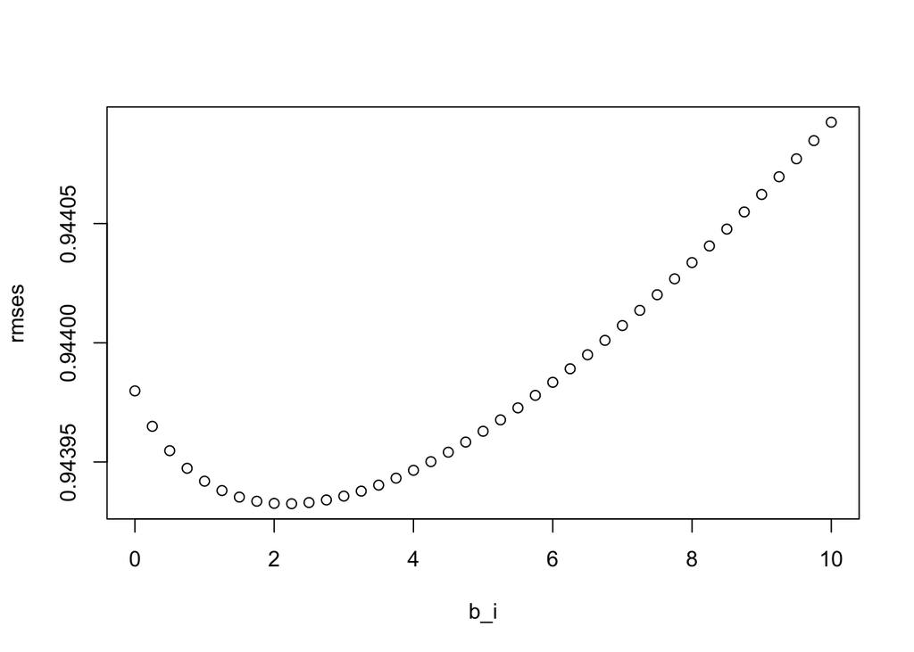

```r
lambdas <- seq(0, 10, 0.25)

rmses <- sapply(lambdas, function(l){
  b_i <- train %>%
    group_by(movieId) %>%
    summarize(b_i = sum(rating - mu)/(n()+l))

  predictions <- test %>%
    left_join(b_i, by='movieId') %>%
    mutate(pred = mu + b_i) %>%
    pull(pred)
  return(RMSE(predictions, test$rating))
})

plot(lambdas,rmses, xlab = "b_i")
```

based on the plot, $\lambda$ that produces the lowest RMSE is chosen.

```r
# get lambda for the lowest rmse
lambdas[which.min(rmses)]
```

```
## [1] 2.25
```

```r
model_reg_bi_rmse <- min(rmses)
rmse_results <- bind_rows(rmse_results,
                          data_frame(method="Regular Movie Effects Model",
                                     RMSE = model_reg_bi_rmse ))
# print table for RMSE
rmse_results %>% kable()
```

| method | RMSE |
| --- | --- |
| Just the average | 1.0598022 |
| Movie Effect | 0.9439798 |
| Movie + User Effects Model | 0.8649803 |
| Regular Movie Effects Model | 0.9439325 |

b_i regularization (1) and b_u = sum(rating - b_i - mu)/(n()+l)

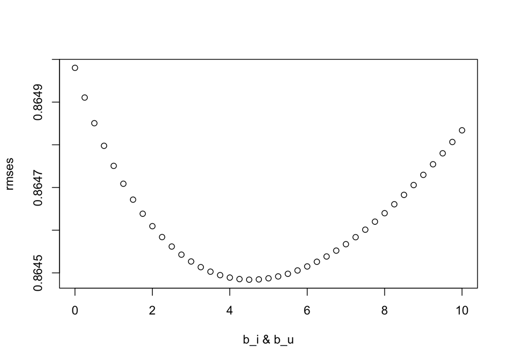

```r
lambdas <- seq(0, 10, 0.25)
rmses <- sapply(lambdas, function(l){
  b_i <- train %>%
    group_by(movieId) %>%
    summarize(b_i = sum(rating - mu)/(n()+l))

  b_u <- train %>%
    left_join(b_i, by="movieId") %>%
    group_by(userId) %>%
    summarize(b_u = sum(rating - b_i - mu)/(n()+l))

  predictions <-
    test %>%
    left_join(b_i, by = "movieId") %>%
    left_join(b_u, by = "userId") %>%
    mutate(pred = mu + b_i + b_u) %>%
    pull(pred)

  return(RMSE(predictions, test$rating))
})

plot(lambdas,rmses, xlab = "b_i & b_u")
```

based on optimization.

```r
# set lambda for the lowest rmse
lambdas[which.min(rmses)]
```

```
## [1] 4.5
```

```r
model_reg_bi_bu_rmse <- min(rmses)

rmse_results <- bind_rows(rmse_results,
                          data_frame(method="Regularized Movie User Effect ",
                                     RMSE = model_reg_bi_bu_rmse ))

# print table for RMSE
rmse_results %>% kable()
```

| method | RMSE |
| --- | --- |
| Just the average | 1.0598022 |
| Movie Effect | 0.9439798 |
| Movie + User Effects Model | 0.8649803 |
| Regular Movie Effects Model | 0.9439325 |
| Regularized Movie User Effect | 0.8644841 |

# 3.1.3. Matrix Factorizing

# using recosystem

```r
library(recosystem)
set.seed(1, sample.kind = "Rounding") # This is a randomized algorithm

####################################################################
# recosystem read only three columns.
# user_index needs to be user index, integer. userId for this data
# item_index needs to be item index, integer. movieId
# rating needs to be numeric. rating
# using data_memory function to include data
train_reco <- data_memory(user_index = train$userId,
                          item_index = train$movieId,
                          rating = train$rating)

test_reco <- data_memory(user_index = test$userId,
                         item_index = test$movieId,
                         rating = test$rating)

# Reco() function creates data files
rec <- Reco()

set.seed(1, sample.kind = "Rounding") # This is a randomized algorithm

# Actual calculation
set.seed(1, sample.kind = "Rounding") # This is a randomized algorithm
rec$train(train_reco, opts = c(nthread  = 4))
```

```
## iter      tr_rmse          obj
##    0       0.9603   1.3246e+07
##    1       0.8807   1.2021e+07
##    2       0.8578   1.1794e+07
##    3       0.8463   1.1651e+07
##    4       0.8416   1.1603e+07
##    5       0.8376   1.1573e+07
##    6       0.8335   1.1546e+07
##    7       0.8300   1.1519e+07
##    8       0.8275   1.1496e+07
##    9       0.8257   1.1482e+07
##   10       0.8244   1.1473e+07
##   11       0.8233   1.1465e+07
##   12       0.8226   1.1456e+07
##   13       0.8220   1.1451e+07
##   14       0.8215   1.1446e+07
##   15       0.8210   1.1444e+07
##   16       0.8207   1.1440e+07
##   17       0.8203   1.1437e+07
##   18       0.8200   1.1433e+07
##   19       0.8198   1.1431e+07
```

```r
# predition from recosystem. For the return, out_memory() should be used.
predictions <- rec$predict(test_reco, out_memory())

# calculate RMSE
model_mat_fac_rmse <- RMSE(predictions, test$rating)

# stroring RMSE
rmse_results <- bind_rows(rmse_results,
                          data_frame(method="Matrix Factorized",
                                     RMSE = model_mat_fac_rmse ))

# print table for RMSE
rmse_results %>% kable()
```

| method | RMSE |
| --- | --- |
| Just the average | 1.0598022 |
| Movie Effect | 0.9439798 |
| Movie + User Effects Model | 0.8649803 |
| Regular Movie Effects Model | 0.9439325 |
| Regularized Movie User Effect | 0.8644841 |
| Matrix Factorized | 0.8326154 |

# 3.2. Final Hold-out Test

using edx and validation sets

# 3.2.1. Regularization with Movie and User effects

b_i regularization (1) and b_u = sum(rating - b_i - mu)/(n()+l) getting lambda for the lowest rmse for regularized bi and bu

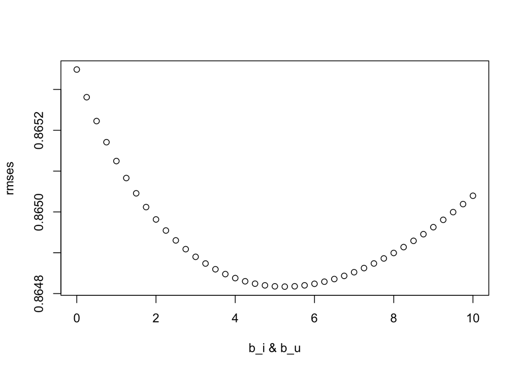

```r
#mu calculation
mu <- mean(edx$rating)

lambdas <- seq(0, 10, 0.25)

rmses <- sapply(lambdas, function(l){
  b_i <- edx %>%
    group_by(movieId) %>%
    summarize(b_i = sum(rating - mu)/(n()+l))

  b_u <- edx %>%
    left_join(b_i, by="movieId") %>%
    group_by(userId) %>%
    summarize(b_u = sum(rating - b_i - mu)/(n()+l))

  predictions <-
    validation %>%
    left_join(b_i, by = "movieId") %>%
    left_join(b_u, by = "userId") %>%
    mutate(pred = mu + b_i + b_u) %>%
    pull(pred)

  return(RMSE(predictions, validation$rating))
})

plot(lambdas,rmses, xlab = "b_i & b_u")
```

based on the optimization

```r
# set lambda for the lowest rmse
lambdas[which.min(rmses)]
```

```
## [1] 5.25
```

```r
model_reg_bi_bu_rmse <- min(rmses)

rmse_results <- bind_rows(rmse_results,
                          data_frame(method="Final Regularized Movie User Effect ",
                                     RMSE = model_reg_bi_bu_rmse ))

# print table for RMSE
rmse_results %>% kable()
```

| method | RMSE |
| --- | --- |
| Just the average | 1.0598022 |
| Movie Effect | 0.9439798 |
| Movie + User Effects Model | 0.8649803 |
| Regular Movie Effects Model | 0.9439325 |
| Regularized Movie User Effect | 0.8644841 |
| Matrix Factorized | 0.8326154 |
| Final Regularized Movie User Effect | 0.8648170 |

# 3.2.2. Matrix Factorizing

```r
library(recosystem)
set.seed(1, sample.kind = "Rounding") # This is a randomized algorithm

# data_memory function to store in recosystem
edx_reco <- data_memory(user_index = edx$userId,
                        item_index = edx$movieId,
                        rating = edx$rating)

validation_reco <- data_memory(user_index = validation$userId,
                               item_index = validation$movieId,
                               rating = validation$rating)

# Reco() function creates data files
rec <- Reco()

# Actual calculation
set.seed(1, sample.kind = "Rounding") # This is a randomized algorithm
rec$train(edx_reco, opts = c(nthread  = 4))
```

```
## iter      tr_rmse          obj
##    0       0.9545   1.4595e+07
##    1       0.8796   1.3350e+07
##    2       0.8562   1.3083e+07
##    3       0.8458   1.2937e+07
##    4       0.8422   1.2891e+07
##    5       0.8395   1.2864e+07
##    6       0.8366   1.2843e+07
##    7       0.8331   1.2819e+07
##    8       0.8300   1.2793e+07
##    9       0.8277   1.2776e+07
##   10       0.8259   1.2756e+07
##   11       0.8247   1.2745e+07
##   12       0.8237   1.2737e+07
##   13       0.8230   1.2733e+07
##   14       0.8225   1.2728e+07
##   15       0.8220   1.2723e+07
##   16       0.8216   1.2718e+07
##   17       0.8213   1.2717e+07
##   18       0.8209   1.2711e+07
##   19       0.8207   1.2710e+07
```

```r
# predition from recosystem. For the return, out_memory() should be used.
predictions <- rec$predict(validation_reco, out_memory())

# store predictions for the movie recommendation
MF_pred <- predictions

# calculate RMSE
model_mat_fac_rmse <- RMSE(predictions, validation$rating)

# stroring RMSE
rmse_results <- bind_rows(rmse_results,
                          data_frame(method="Final Matrix Factorized",
                                     RMSE = model_mat_fac_rmse ))

# print table for RMSE
rmse_results %>% kable()
```

| method | RMSE |
| --- | --- |
| Just the average | 1.0598022 |
| Movie Effect | 0.9439798 |
| Movie + User Effects Model | 0.8649803 |
| Regular Movie Effects Model | 0.9439325 |
| Regularized Movie User Effect | 0.8644841 |
| Matrix Factorized | 0.8326154 |
| Final Regularized Movie User Effect | 0.8648170 |
| Final Matrix Factorized | 0.8325002 |

# 4. Conclusion Summary

Summary Table

```r
# Summary table for RMSE
rmse_results %>% kable()
```

| method | RMSE |
| --- | --- |
| Just the average | 1.0598022 |
| Movie Effect | 0.9439798 |
| Movie + User Effects Model | 0.8649803 |
| Regular Movie Effects Model | 0.9439325 |
| Regularized Movie User Effect | 0.8644841 |
| Matrix Factorized | 0.8326154 |
| Final Regularized Movie User Effect | 0.8648170 |
| Final Matrix Factorized | 0.8325002 |

Limitation

Future Works

Reference